# Some thoughts on assessing risk and in particular the risk of contracting covid 19.

Once again I'm indebted to Rick Wicklin's Blog, the Do Loop for the ideas presented here ( https://blogs.sas.com/content/iml/2020/04/08/reducing-spread-of-coronavirus.html)

While I think it is intuitively clear that social distancing and quarantine are effective in reducing risk, it might be useful to quantify this a bit. In this post, I'm going to examine and discuss the concept of risk and use a simple statistical model to examine why social distancing works. This will allow us to put some numbers around how effective social distancing is.

As you know, I used to teach statistics at both the undergraduate and the graduate level. When teaching statistical modeling, I always started my presentations with a statement attributed to George Box: "All models are wrong -- but some are useful." I think this is appropriate in the present setting. I'm going to make some assumptions that are clearly a simplication of the real world, but the results are useful.

# Preliminaries

### Thinking about risk

We usually think about risk as a probability. The question is how big is the risk.

A Scottish statistician, Fergus Simpson, uses dice (https://medium.com/@fergus2/coronavirus-a-personal-risk-assessment-50003c952c03) to quantify risk. He suggests considering tossing multiple dice and asking what's the probability that all of them end with a six up.  
For one die, the probability is 1/6 for two dice it's 1/36 and so on. The more dice you toss, the lower the risk. He then equates some probabilities to the number of dice you have. (Flying, for example is a nine disk risk, somewhere around 1 in 10 million.)

In his article Wicklyn uses three probabilities:  
p = 1/2 = 0.5: the probability of "heads" when you toss a coin  
p = 1/6 = 0.166: the probability of rolling a 6 with a six-sided die  
p = 1/13 = 0.077: the probability of drawing an ace from a shuffled deck of 52 cards

For those of you who know Texas-Holdem poker, the probability of drawing pocket aces is $\frac{1}{211} \approx .005.$

The US covid 19 confirmed cases count is over 3,000,000 as of today (7/13/2020. So if we selected a random US citizen, the probability that they are infected is near .01. How accurate this number is, no one really knows, but I'm going to use it to examine the question:

*If the probability of a random person being infected is only .01 why should I worry?*

The thing one tends to forget is that if $p=.01$ for any single random contact, that does not mean the probability is that low if we have multiple contacts. Each contact one makes can be considered a "trial" and the more contacts the higher the probability of contracting the disease. We'll use the geometric distribution to demonstrate this.

## The geometric statistical distribution.

The model starts with the assumption that we do an experiment, called a Bernoulli trial. A Bernoulli trial has two possible outcomes, failure and success. Some, examples:  
Draw as single card from a will shuffled deck of 52 cards. What is the probability that we draw an ace? In this case, we consider drawing an ace as "success" and not drawing an ace is "failure." The probability of success is $\frac{4}{52} = \frac{1}{13}.$

Interestingly, we often label as "success" the outcome that we are interested in even when it could not be considered success in any way (e.g., developing heart disease or cancer).

In our case we are going to consider success becoming infected with the virus and consider the Bernoulli trial to be coming in contact with a random person. If that person is infectious, we assume we will be infected. We will use $p=.01$ as the probability of being infected

If we come in contact with a single person the probability of infection is $p=.01$. What if we come in contact with more than one person?

The geometric distribution examines what the probability is with multiple or repeated Bernoulli trials, each of which has the probability $p$ of being a success. Each time we come in contact with a random person the probability of infection is $p=.01$. In statistics these repeated Bernoulli trials are sometimes modeled with the geometric distribution. Social distancing and quarantining does not change the probability, rather it reduces the number of times we come in contact with random individuals.

The geometric distribution, unfortunately has two different defintions:

1. How many trials occur until the first success.
2. On what trial does the first success occur.

The two definitions are equivalent, the bookkeeping differs. I'm going to use the second definition only because that is the definition used in the scipy.stats library in python.

We then ask, what's the probability that the first success occurs on the $k^{th}$ trial. (We assume the trials are independent.)
$$\Pr(k \text{ being the first success} | p) = (1-p)^{k-1}p$$

All the formula says is that to get the infection on the $k^{th}$ trial we didn't get infected on the first $k-1$ trials.

### To understand the formula $\Pr(k \text{ being the first success} | p) = (1-p)^{k-1}p$ let's do a little arithmetic

In our case if we come in contact with one person and that person is infected, the probability of infection is just $p=.01$, which and be written as (since $(1-p)^0$ is $1$ by definition):
$$\Pr(k \text{ being the first success} | p=.01,k=1) = (1-p)^{k-1}p=(1-.01)^0*.01 = .01$$

If we come in contact with two people, the first success can only happen if the first contact was uninfected and the second was infected. The probability of this exact sequence is $(1-p)p$: $$\Pr(k \text{ being the first success} | p=.01,k=2) = (1-p)p=(1-.01)^1*.01 = 0.0099$$

What we can now ask is what is the probability that we were infected for the first time by the first or the second contact? This is just the sum of two probabilities -- the probability that we were infected by the first contact or the second contact:
$$\Pr(k=1 \text{ or } k=2 \text{ being the first success} | p=.01) = .01+0.0099 = .0199$$

So for just two contacts, we have almost doubled the probability of becoming infected. We could go on with the aritmetic, but with computers it's easy to examine this in more detail.

The following table gives the probability (using the geometric distribution) that we become infected within the specified number of contacts, when $p=.01$.

| Number of contacts | Probability |
| --- | --- |
| 1 | 0.010000 |
| 10 | 0.095618 |
| 20 | 0.182093 |
| 30 | 0.260300 |
| 40 | 0.331028 |
| 50 | 0.394994 |
| 60 | 0.452843 |
| 70 | 0.505161 |
| 80 | 0.552477 |
| 90 | 0.595268 |
| 100 | 0.633968 |

With just forty contacts (not that many when you think of our usual routines that include shopping, restaurants, etc.) the probability of infection is about $\frac{1}{3}.$

The following graph displays the cumulative probability of infection for several values of $p$.

The point is that if we reduce the number of contacts, or reduce the probability of being infected given we come in contact with an infected person (perhaps with masks), we simultaneously reduce the probability of becoming infected.

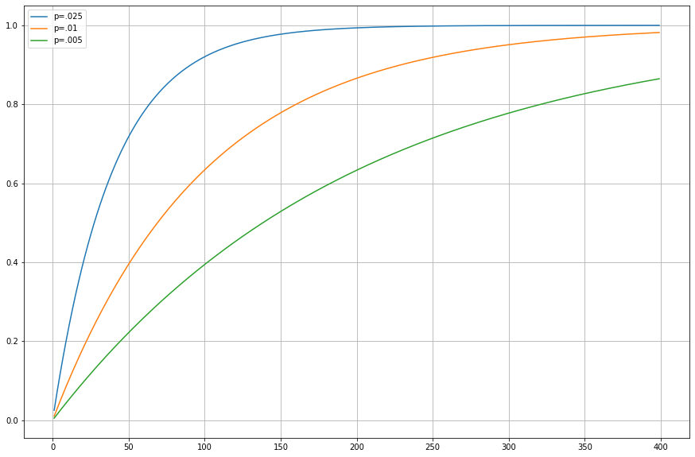

To quote Wicklin, "The geometric distribution isn't complex enough to be realistic." And even if it were true, exactly what $p$, the probability of coming in contact with an infected individual is not known with any precision and surely varies from place to place. But it should convince us that even with small probabilities for a single contact, multiple contacts can lead to much higher risk (probability).